# Analizando las letras de tango

En este notebook la idea es analizar las letras de tango. Se realizó *web scraping* del sitio [milongeando.it](http://milongueando.it/letras_testi_di_tango/index.html) para obtener 768 letras de diferentes canciones de tango.

Las preguntas que quiero contestar son:

- ¿Cuáles son las palabras más utilizadas?
- ¿Es el tango tan negativo en sus letras? ¿Qué nos dice un análisis de sentimiento?
- ¿Qué temas encontramos en las letras?

```r
#Carga de datos
library(tidyverse)
library(tm)
library(tidytext)

data <- read.csv("tango_lyrics.csv", sep = "|")
```

Primero hay que procesar los datos. Para eso, se creó la función “clean_corpus” para limpiar el texto recolectado. Esta función realiza las siguientes tareas de limpieza:

- Convertir todas las mayúsculas en minúsculas.
- Eliminar todos los signos de puntuación: aunque es usualmente frecuente para la minería de texto realizar esta tarea, dependiendo del análisis deseado el uso de signos de puntuación puede ser información valiosa. Sin embargo, este no es el caso.
- Eliminar los espacios en blanco extra.
- Eliminar todos los números.
- Eliminar las palabras que en español entorpecen el análisis: “nosotros”, “mucho” y “nada” son palabras que sirven más como conectores y no tienen un significado valioso en el análisis.

Una vez que las letras de tango ya fueron procesadas se procede a eliminar todos los tildes presentes en las palabras. Si no se realiza este paso, podríamos llegar a encontrar términos como “corazón” y “corazon”, que nos arrojarían frecuencias diferentes ya que serían computados como palabras diferentes. Luego se comienzan a reordenar los datos en formato de tabla, en la cual en una columna se encuentra la palabra, y en la otra la cantidad de veces que aparece en todas las letras recoletadas.

```r
#Procesamiento de datos
clean_corpus <- function(corpus){
  corpus <- tolower(corpus)
  corpus <- removePunctuation(corpus)
  corpus <- stripWhitespace(corpus)
  corpus <- removeNumbers(corpus)
  corpus <- removeWords(corpus, stopwords("es"))
  return(corpus)
}

data$lyric <- clean_corpus(data$lyric)
data$lyric <- iconv(data$lyric, to='ASCII//TRANSLIT')

tidy_data <- data %>%
  unnest_tokens(word, lyric) %>%
  count(word, title) %>%
  group_by(word, title) %>%
  ungroup()
```

Una vez que tenemos los datos presentados de una manera más prolija, se pueden realizar gráficos de frecuencia de palabras.

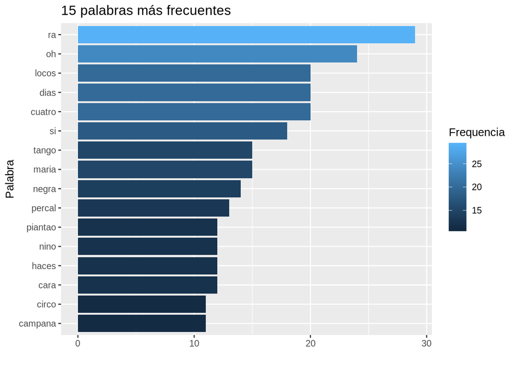

```r
#Graficando
tidy_data %>%
  top_n(15) %>%
  ggplot(aes(x = reorder(word, n), y = n, fill = n)) +
  geom_bar(stat='identity') +
  coord_flip() +
  labs(x = "Palabra", y = "", fill = "Frequencia", title="15 palabras más frecuentes")
```

> Todo eso hace del tango una danza introvertida y hasta introspectiva: un pensamiento triste que se baila.

Con este cuadro podemos inferir que el tango es escencialmente triste. Pero eso no es una conclusión adecuada. Para tener una posición más fundamentada mejor es realizar un análisis de sentimiento. Esto es, en este caso, buscar la polaridad de las letras de tango. Es decir, la frecuencia de palabras negativas y positivas utilizadas. Dado que no existe alguna otra variable que nos pueda indicar el sentimiento (por ejemplo, un *score* de cada letra). Para realizar una análisis de sentimiento se utilizan los datos disponibles en un [kernel de Kaggle](https://www.kaggle.com/rtatman/sentiment-lexicons-for-81-languages/home) que fue realizado en base al paper de [Chen y Skiena](http://www.aclweb.org/anthology/P14-2063). Se unieron los dos archivos con palabras positivas y negativas para el idioma español en un archivo llamado *spanish-sentiment.csv*.

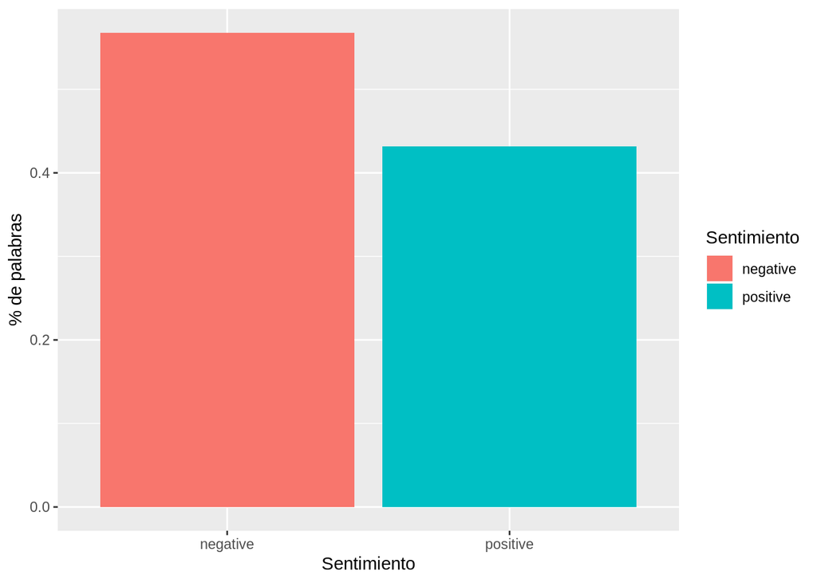

```r
lexicon <- read.csv("spanish-sentiment.csv")
tidy_data_sent <- tidy_data %>%
  inner_join(lexicon)

tidy_data_sent %>%
  group_by(sentiment) %>%
  summarise(n = n()) %>%
  mutate(freq = n / sum(n)) %>%
  ggplot(aes(sentiment,freq, fill = sentiment)) +
  geom_col() +
  labs(x="Sentimiento", y="% de palabras", fill="Sentimiento")
```

La cita de Sábato es cierta. Las letras de tango son más negativas en base a las palabras que contienen. En total, casi un 60% de las palabras son negativas mientras poco más del 40% son positivas. Por último queda resolver la cantidad de temas sobre los que versan las letras recolectadas. Vamos a ver los resultados agrupando en 2 y en 5 tópicos:

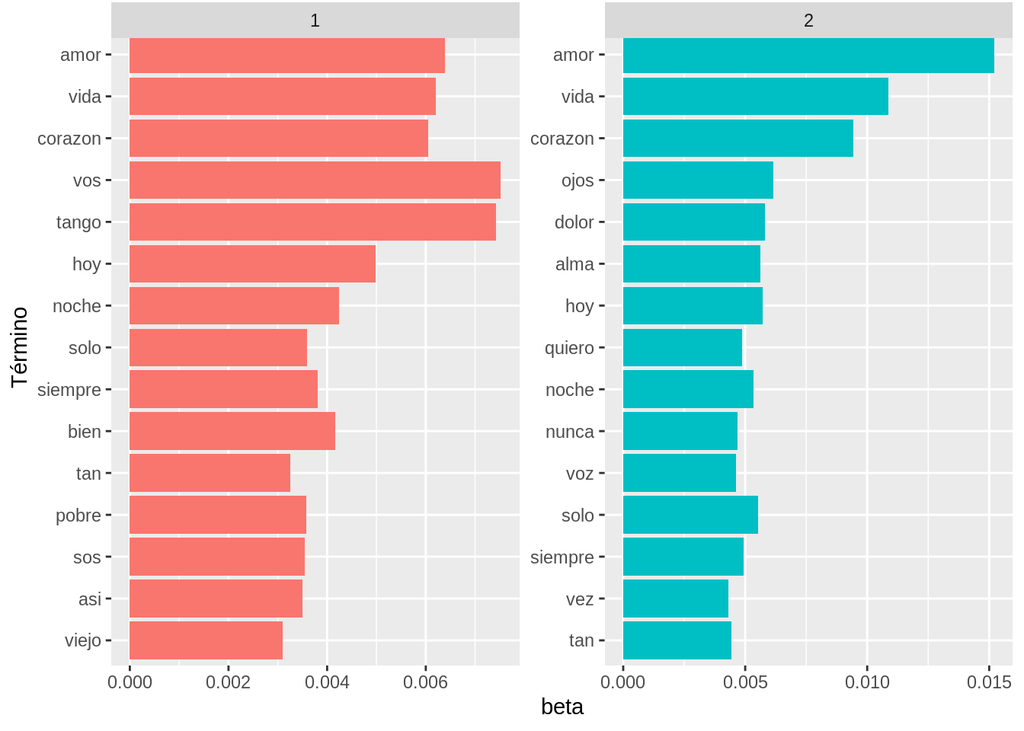

```r
library(topicmodels)

clean_text <- as.data.frame(data$lyric)
colnames(clean_text) <- c("text")
clean_text <- DataframeSource(clean_text)
clean_text <- VCorpus(clean_text)
corpus_dtm <- DocumentTermMatrix(clean_text)
lda_2 <- LDA(corpus_dtm, k=2, control = list(seed=1234))
lda_topics <- tidy(lda_2, matrix = "beta")

top_terms <- lda_topics %>%
  group_by(topic) %>%
  top_n(15, beta) %>%
  ungroup() %>%
  arrange(topic, -beta)

top_terms %>%
  mutate(term = reorder(term, beta)) %>%
  ggplot(aes(term, beta, fill = factor(topic))) +
  geom_col(show.legend = FALSE) +
  facet_wrap(~ topic, scales = "free") +
  coord_flip() +
  labs(x="Término")
```

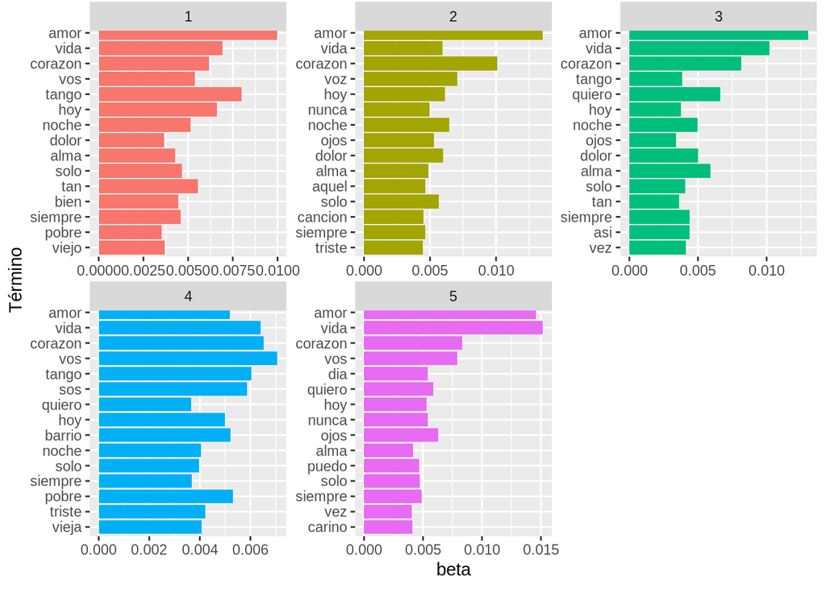

```r
lda_5 <- LDA(corpus_dtm, k=5, control = list(seed=1234))
lda_topics <- tidy(lda_5, matrix = "beta")

top_terms <- lda_topics %>%
  group_by(topic) %>%
  top_n(15, beta) %>%
  ungroup() %>%
  arrange(topic, -beta)

top_terms %>%
  mutate(term = reorder(term, beta)) %>%
  ggplot(aes(term, beta, fill = factor(topic))) +
  geom_col(show.legend = FALSE) +
  facet_wrap(~ topic, scales = "free") +
  coord_flip() +
  labs(x="Término")
```

Como se pueden ver en los dos gráficos, los términos utilizados en los diferentes tópicos se encuentran muy interrelacionados entre si. El valor del **alpha** para cada uno de las pruebas de este modelo resulta muy bajo como para indicar que hay una separación clara entre los distintos temas (0.0777 y 0.0247 respectivamente).